# CN Distribution Part 1 analysis

Mark R. Williamson

5 September 2024

# Introduction

The purpose of this analysis is to answer a variety of research hypotheses for the **First** paper in CN distribution.

Research hypotheses:  
1) How are copy number repeats of the rRNA operon distributed in prokaryotes?  
2) What is the phylogenetic signal of CN distribution?  
3) Do CN distributions different across domain (Archaea vs. Bacteria)?  
4) Do CN distributions cluster by taxa (for each CN)?  
5) Is CN distribution predicted by genome characteristics?

# Part 0: Getting packages and datasets in

## Datasets

```r
#Datasets
setwd("C:/Users/Mark.Williamson.2/OneDrive - North Dakota University System/Desktop/Williamson Projects/Copy Number/CN Distribution/")

#M1 -aka base dataset
Pro_CN <-read.csv("M1.csv")
names(Pro_CN)
```

```
##  [1] "accession"          "domain"             "species"
##  [4] "CN"                 "range"              "average"
##  [7] "range_no_cross"     "average_no_cross"   "range_normalized"
## [10] "average_normalized"
```

```r
head(Pro_CN)
```

```
##     accession   domain
## 1 NZ_CP056121 Bacteria
## 2 NZ_CP056120 Bacteria
## 3 NZ_CP056122 Bacteria
## 4 NZ_CP090501 Bacteria
## 5 NZ_CP090498 Bacteria
## 6 NZ_CP090487 Bacteria
##                                                       species CN  range
## 1                                            Moritella sp. 28 20 0.2655
## 2                                            Moritella sp. 36 20 0.2700
## 3                                             Moritella sp. 5 20 0.2748
## 4     Photobacterium damselae subsp. damselae strain CSP DAM1 20 0.4086
## 5     Photobacterium damselae subsp. damselae strain CSP DAM2 20 0.4086
## 6 Photobacterium damselae subsp. damselae strain AS-15-3942-9 20 0.4154
##      average range_no_cross average_no_cross range_normalized
## 1 0.01397368         0.9888       0.05204210        0.2794737
## 2 0.01421053         0.9888       0.05204210        0.2842105
## 3 0.01446316         0.9886       0.05203158        0.2892632
## 4 0.02150526         0.9758       0.05135790        0.4301053
## 5 0.02150526         0.9758       0.05135790        0.4301053
## 6 0.02186316         0.9753       0.05133158        0.4372632
##   average_normalized
## 1          0.2794737
## 2          0.2842105
## 3          0.2892632
## 4          0.4301053
## 5          0.4301053
## 6          0.4372632
```

```r
#M1_gens -includes genome size
M1_gens <- read.csv("M1_gens.csv")
names(M1_gens)
```

```
##  [1] "accession"        "domain"           "species"          "CN"
##  [5] "CN_1"             "CN_2"             "CN_3"             "CN_4"
##  [9] "CN_5"             "CN_6"             "CN_7"             "CN_8"
## [13] "CN_9"             "CN_10"            "CN_11"            "CN_12"
## [17] "CN_13"            "CN_14"            "CN_15"            "CN_16"
## [21] "CN_17"            "CN_18"            "CN_19"            "CN_20"
## [25] "d_2_1"            "d_3_2"            "d_4_3"            "d_5_4"
## [29] "d_6_5"            "d_7_6"            "d_8_7"            "d_9_8"
## [33] "d_10_9"           "d_11_10"          "d_12_11"          "d_13_12"
## [37] "d_14_13"          "d_15_14"          "d_16_15"          "d_17_16"
## [41] "d_18_17"          "d_19_18"          "d_20_19"          "d_1_n"
## [45] "max"              "sum"              "range"            "length"
## [49] "average"          "range_no_cross"   "average_no_cross" "genome_size"
```

```r
head(M1_gens)
```

```
##     accession   domain                                             species CN
## 1 NZ_CP036246 Bacteria               Arcobacter porcinus strain CCUG 56899  4
## 2   NC_005957 Bacteria Bacillus thuringiensis serovar konkukian str. 97-27 14
## 3 NZ_CP025074 Bacteria                 Bacillus caldolyticus strain NEB414  9
## 4   NC_014219 Bacteria                     Bacillus selenitireducens MLS10  7
## 5 NZ_CP011309 Bacteria             Brevibacterium flavum strain ATCC 15168  6
## 6    CP079240 Bacteria                 Brevibacterium flavum strain CCM251  5
##     CN_1   CN_2   CN_3   CN_4   CN_5   CN_6   CN_7   CN_8   CN_9  CN_10  CN_11
## 1 0.2228 0.4083 0.7153 0.9683     NA     NA     NA     NA     NA     NA     NA
## 2 0.0018 0.0056 0.0157 0.0168 0.0289 0.0482 0.0521 0.0534 0.0548 0.0567 0.0581
## 3 0.4202 0.5012 0.5108 0.5400 0.5587 0.5766 0.5822 0.7578 0.9832     NA     NA
## 4 0.0032 0.0098 0.0247 0.0264 0.1599 0.3799 0.8185     NA     NA     NA     NA
## 5 0.0320 0.2731 0.4646 0.7976 0.8002 0.9390     NA     NA     NA     NA     NA
## 6 0.0318 0.2723 0.4637 0.8010 0.9394     NA     NA     NA     NA     NA     NA
##    CN_12  CN_13  CN_14 CN_15 CN_16 CN_17 CN_18 CN_19 CN_20  d_2_1  d_3_2  d_4_3
```

[output cut: 27 more lines]

```r
#M4 -includes clear taxonomy
M4 <-read.csv("M4.csv")
names(M4)
```

```
##  [1] "accession"  "species"    "domain"     "phylum"     "class"
##  [6] "order"      "family"     "genus"      "CN"         "range"
## [11] "average"    "range_nc"   "average_nc"
```

```r
head(M4)
```

```
##     accession                                             species   domain
## 1 NZ_CP036246               Arcobacter porcinus strain CCUG 56899 Bacteria
## 2   NC_005957 Bacillus thuringiensis serovar konkukian str. 97-27 Bacteria
## 3 NZ_CP025074                 Bacillus caldolyticus strain NEB414 Bacteria
## 4   NC_014219                     Bacillus selenitireducens MLS10 Bacteria
## 5 NZ_CP011309             Brevibacterium flavum strain ATCC 15168 Bacteria
## 6    CP079240                 Brevibacterium flavum strain CCM251 Bacteria
##             phylum           class             order                family
## 1 Campilobacterota Campylobacteria Campylobacterales       Arcobacteraceae
## 2       Firmicutes         Bacilli        Bacillales         Bacillaceae 1
## 3       Firmicutes         Bacilli        Bacillales         Bacillaceae 1
## 4       Firmicutes         Bacilli        Bacillales Sporolactobacillaceae
## 5   Actinobacteria  Actinobacteria   Mycobacteriales    Corynebacteriaceae
## 6   Actinobacteria  Actinobacteria   Mycobacteriales    Corynebacteriaceae
##                                  genus CN  range    average range_nc average_nc
## 1                        Aliarcobacter  4 0.6930 0.23100000   0.7455 0.24850000
## 2                             Bacillus 14 0.2500 0.01923077   0.8880 0.06830769
## 3                          Geobacillus  9 0.5630 0.07037500   0.5630 0.07037500
## 4 Sporolactobacillaceae_incertae_sedis  7 0.5614 0.09356667   0.8153 0.13588333
## 5                      Corynebacterium  6 0.6670 0.13340000   0.9070 0.18140000
## 6                      Corynebacterium  5 0.6627 0.16567500   0.9076 0.22690000
```

```r
#GC content and gene number
GCgene <- read.csv("GC_content_gene_number_finale_2024.csv")
names(GCgene)
```

```
## [1] "accession"  "GC_Content" "tRNAs"      "Cgenes"     "Pgenes"
## [6] "CRISPR"
```

```r
head(GCgene)
```

```
##   accession GC_Content tRNAs Cgenes Pgenes CRISPR
## 1  OU997945     28.609     .      .      .      .
## 2 NC_000964     43.514    86   4237     88      .
## 3 NC_016845     57.485    62   5779      0      .
## 4 NC_002695     50.537   103   5155    136      .
## 5 NC_004337     50.889    97   4313    343      .
## 6  CP006698     50.761     .      .      .      .
```

```r
#M1_phen -includes phenotypic data from subset of isolates, NOT USED HERE
#M1_phen <- read.csv("M1_phen.csv")
#names(M1_phen)
#head(M1_phen)

#PLACEHOLDER FOR MORE DATASETS
```

Phenotypic data reference: [A synthesis of bacterial and archaeal phenotypic trait data](https://www.nature.com/articles/s41597-020-0497-4) condensed_traits_NCBI.csv ***

# Part 1: How are copy number repeats of the rRNA operon distributed in prokaryotes?

## Overall CN distribution

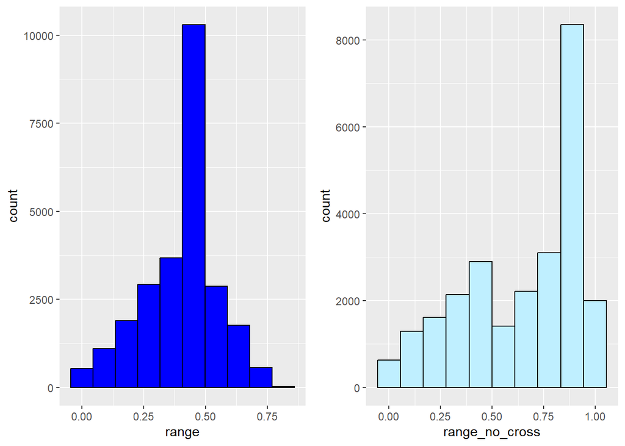

```r
#histograms
h1 <- ggplot(data=Pro_CN, aes(range))+
  geom_histogram(bins=10, fill="blue", col="black")

h2 <- ggplot(data=Pro_CN, aes(average))+
  geom_histogram(bins=10, fill="indianred4", col="black")

h3 <- ggplot(data=Pro_CN, aes(range_no_cross))+
  geom_histogram(bins=10, fill="lightblue1", col="black")

h4 <- ggplot(data=Pro_CN, aes(average_no_cross))+
  geom_histogram(bins=10, fill="indianred1", col="black")

plot_grid(h1, h3)
```

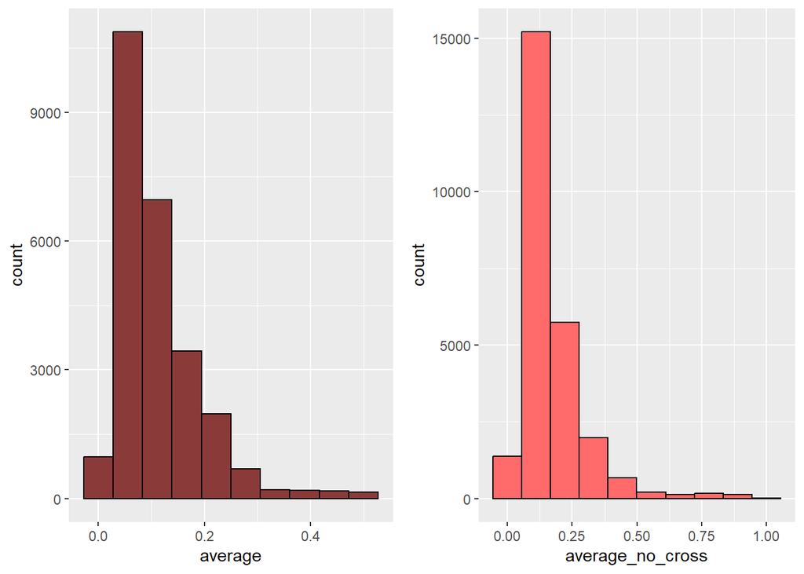

```r
plot_grid(h2, h4)
```

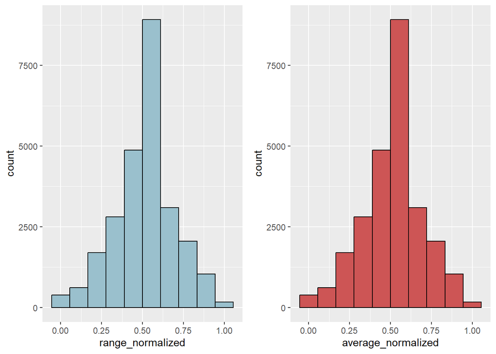

```r
h5 <- ggplot(data=Pro_CN, aes(range_normalized))+
  geom_histogram(bins=10, fill="lightblue3", col="black")

h6 <- ggplot(data=Pro_CN, aes(average_normalized))+
  geom_histogram(bins=10, fill="indianred3", col="black")

plot_grid(h5, h6)
```

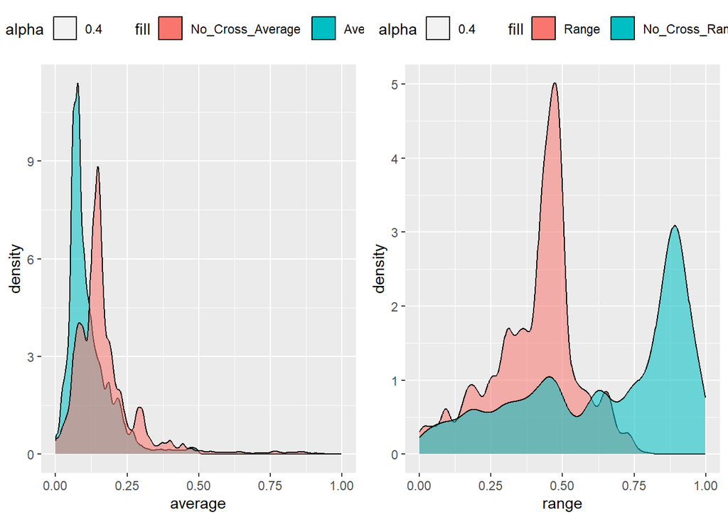

```r
#density plots
d1 <-ggplot(data=Pro_CN)+
  geom_density(aes(x=average, fill="indianred4", alpha=0.4))+
  geom_density(aes(x=average_no_cross, fill="indianred1", alpha=0.4))+
  scale_fill_discrete(labels=c("No_Cross_Average","Average"))+
  theme(legend.position="top")

d2 <-ggplot(data=Pro_CN)+
  geom_density(aes(x=range, fill="blue", alpha=0.4))+
  geom_density(aes(x=range_no_cross, fill="lightblue1", alpha=0.4))+
  scale_fill_discrete(labels=c("Range","No_Cross_Range"))+
  theme(legend.position="top")
plot_grid(d1, d2)
```

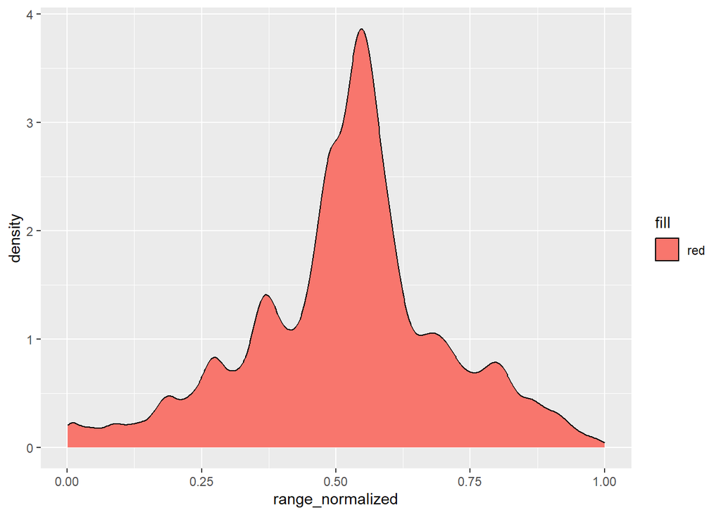

```r
d3 <-ggplot(data=Pro_CN)+
  geom_density(aes(x=range_normalized, fill="red"))
d3
```

Density plot ref: http://sthda.com/english/wiki/ggplot2-density-plot-quick-start-guide-r-software-and-data-visualization  
Conclusion: **Go with range and average, not the no-cross ones** ***

## Overall correlation between Average, Range, and Range Normalized

```r
Pro_CN_cordf <-na.exclude(data.frame(range=Pro_CN$range,
                                    average=Pro_CN$average,
                                    rangenorm=Pro_CN$range_normalized,
                                    CN=Pro_CN$CN))
cor1 <-cor(Pro_CN_cordf[,0:3])
cor1
```

```
##               range   average rangenorm
## range     1.0000000 0.1926505 0.9082242
## average   0.1926505 1.0000000 0.5856144
## rangenorm 0.9082242 0.5856144 1.0000000
```

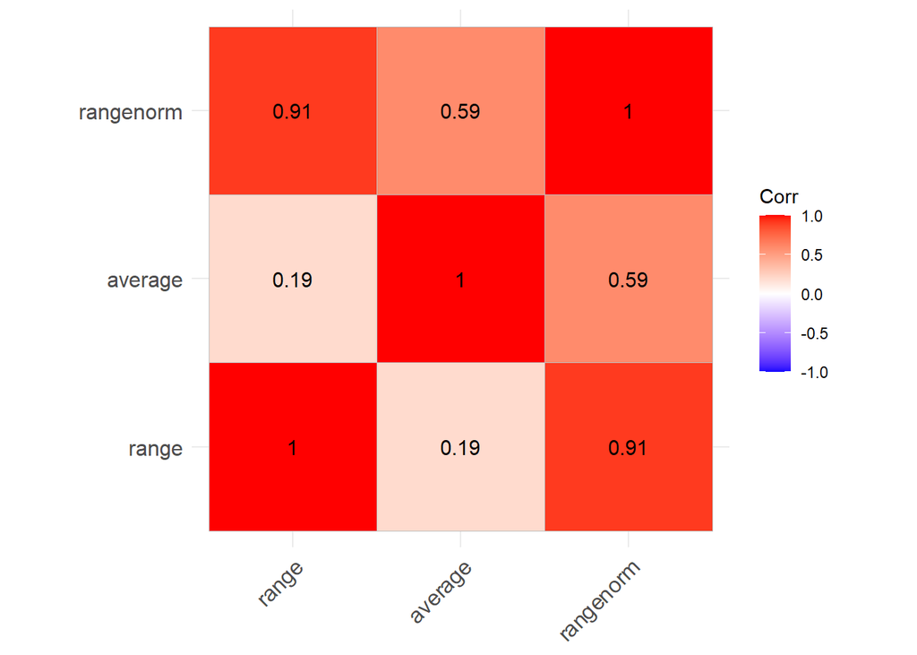

```r
ggcorrplot(cor1, lab=TRUE)
```

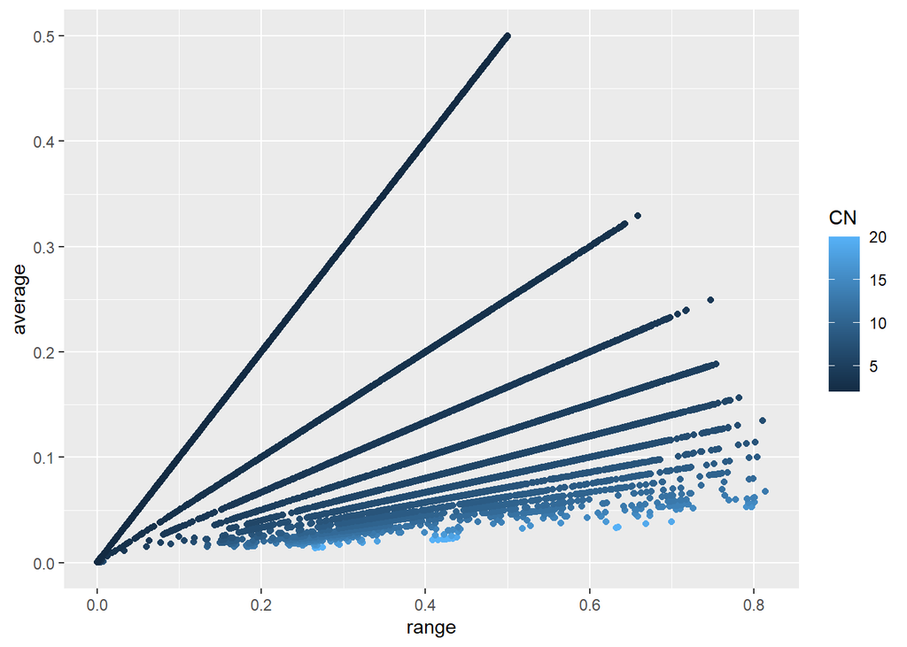

```r
ggplot(data=Pro_CN_cordf, aes(x=range, y=average, color=CN)) +
  geom_point()
```

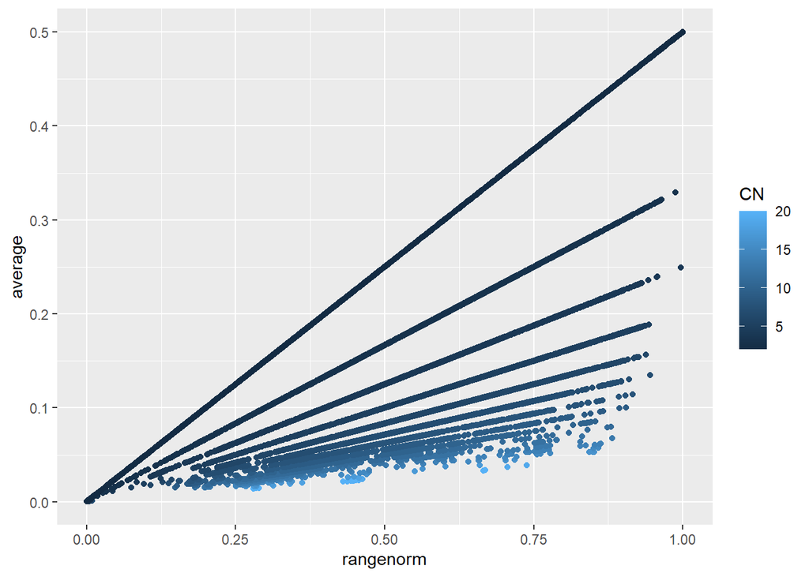

```r
ggplot(data=Pro_CN_cordf, aes(x=rangenorm, y=average, color=CN)) +
  geom_point()
```

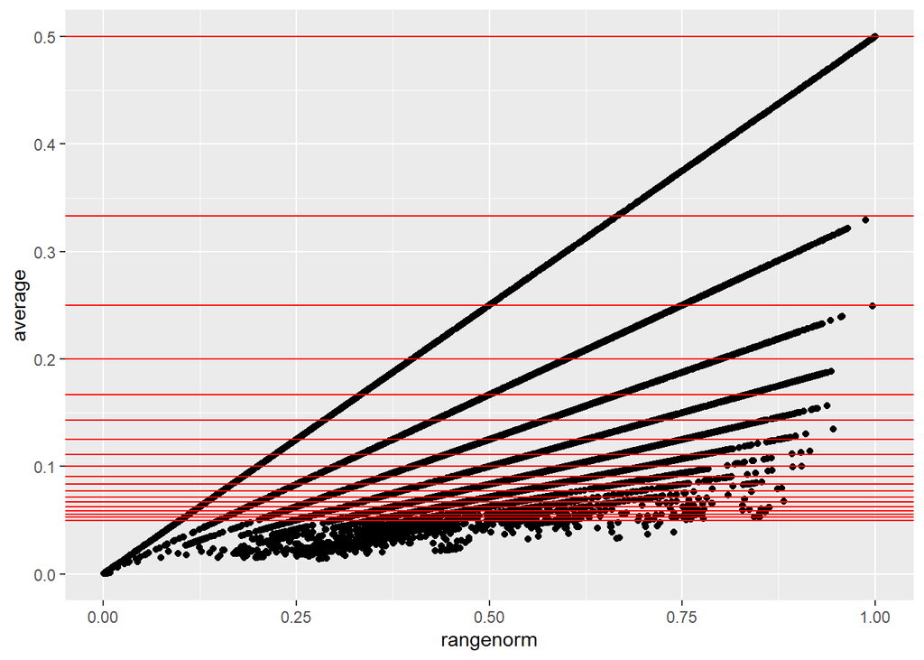

```r
cfig1 <- ggplot(data=Pro_CN_cordf, aes(x=rangenorm, y=average)) +
  geom_point() +
  geom_hline(aes(yintercept=(1/CN)), col="red")
cfig1
```

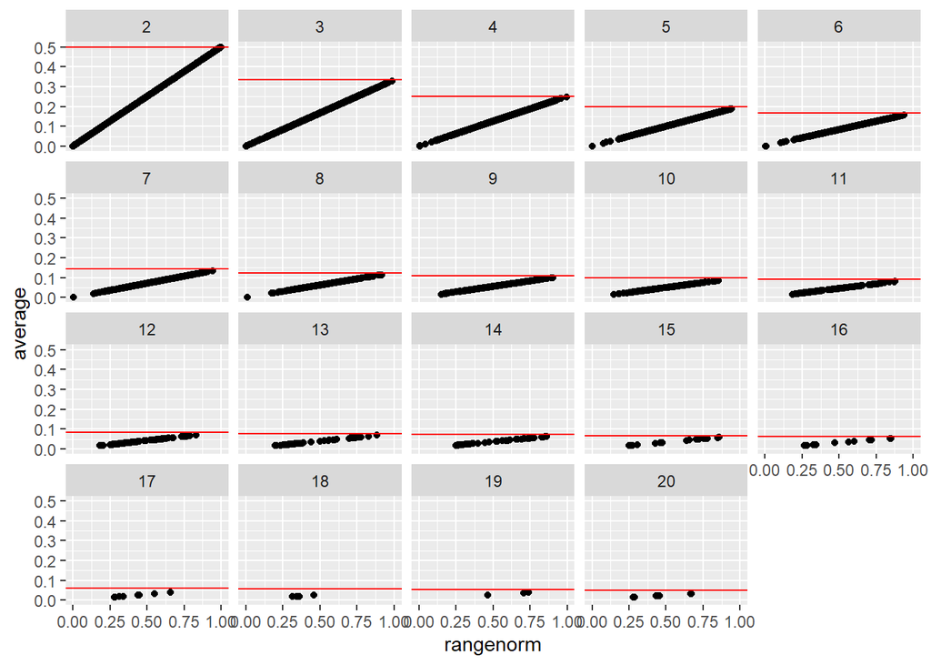

```r
cfig1 + facet_wrap(~CN, ncol=5)
```

Range Normalized is perfectly correlated with average within copy number  
Average Normalized is identical to Range Normalized  
Will use **normalized range** as the metric for further analyses  
***

## CN distribution summaries across Copy Number

```r
#frequency table of CN
table(Pro_CN$CN)
```

```
##
##    2    3    4    5    6    7    8    9   10   11   12   13   14   15   16   17
## 3472 3526 2879 2015 3787 5074 2577  623  687  346  224  121  245   26   13    8
##   18   19   20
##    4    3   14
```

```r
#New column with CN>10 being in one group
Pro_CN$CN_g2 <-with(Pro_CN, ifelse(CN <=10, as.character(CN), '11+'))
Pro_CN$CN_g2 <-factor(Pro_CN$CN_g2, levels=c("1","2","3","4","5","6","7","8","9","10","11+"))
table(Pro_CN$CN_g2)
```

```
##
##    1    2    3    4    5    6    7    8    9   10  11+
##    0 3472 3526 2879 2015 3787 5074 2577  623  687 1004
```

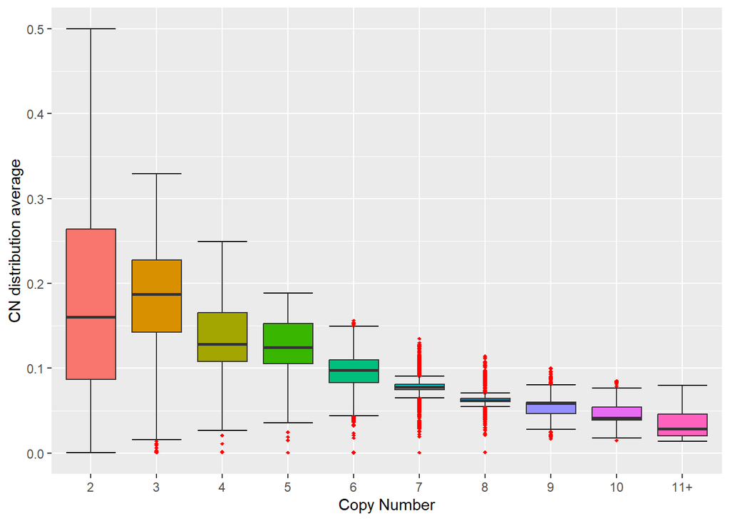

```r
ggplot(data=Pro_CN, aes(x=CN_g2, y=average, fill=CN_g2)) +
  stat_boxplot(geom ='errorbar') +
  geom_boxplot(outlier.colour="red", outlier.shape=18, outlier.size=1) +
  labs(x="Copy Number", y="CN distribution average") +
  theme(legend.position="none")
```

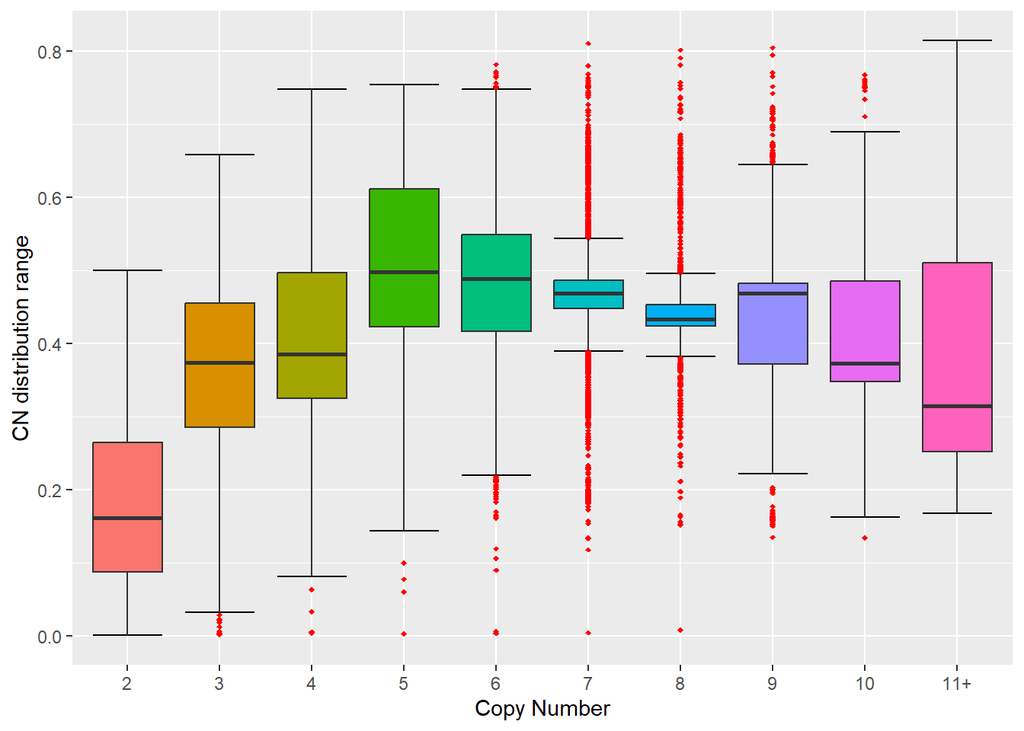

```r
ggplot(data=Pro_CN, aes(x=CN_g2, y=range, fill=CN_g2)) +
  stat_boxplot(geom ='errorbar') +
  geom_boxplot(outlier.colour="red", outlier.shape=18, outlier.size=1) +
  labs(x="Copy Number", y="CN distribution range") +
  theme(legend.position="none")
```

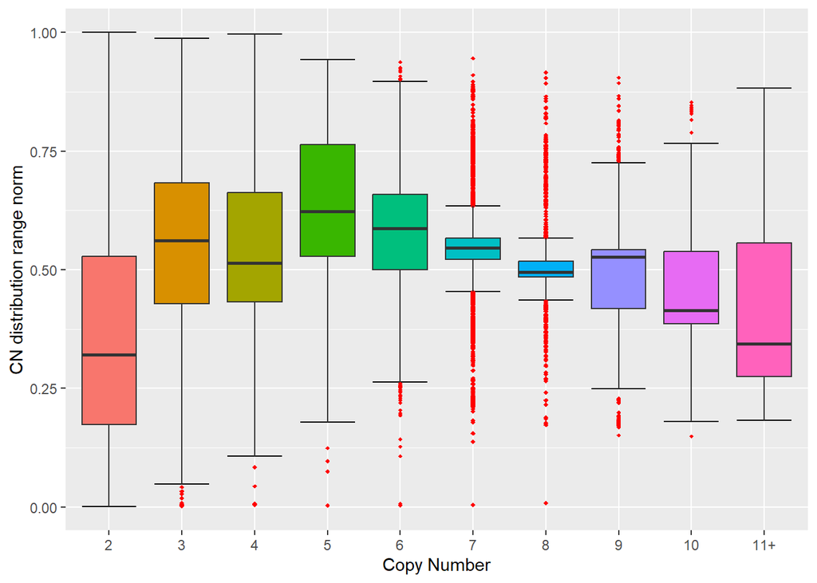

```r
ggplot(data=Pro_CN, aes(x=CN_g2, y=range_normalized, fill=CN_g2)) +
  stat_boxplot(geom ='errorbar') +
  geom_boxplot(outlier.colour="red", outlier.shape=18, outlier.size=1) +
  labs(x="Copy Number", y="CN distribution range norm") +
  theme(legend.position="none")
```

average normalized is the same as range normalized. ***

## CN distribution across domain

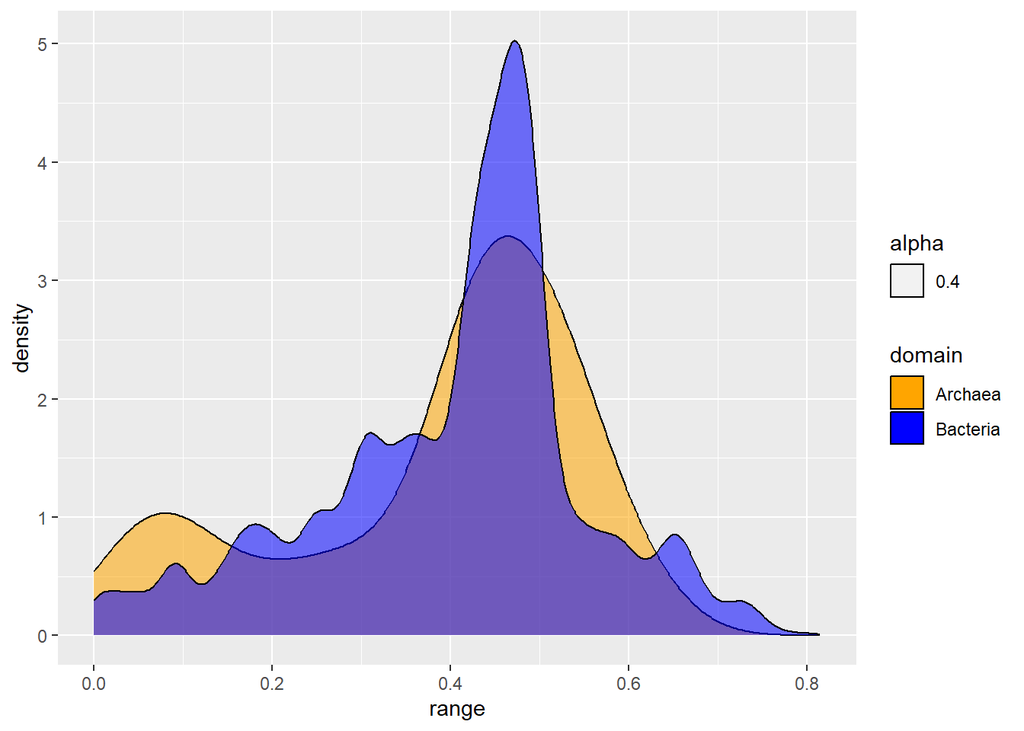

```r
#Bacteria vs. Archaea

  #Total Bacteria vs. Total Archaea

    #Density plots
ggplot(Pro_CN)+
  geom_density(aes(x=range, fill=domain, alpha=0.4))+
  scale_fill_manual(values=c("orange","blue"))
```

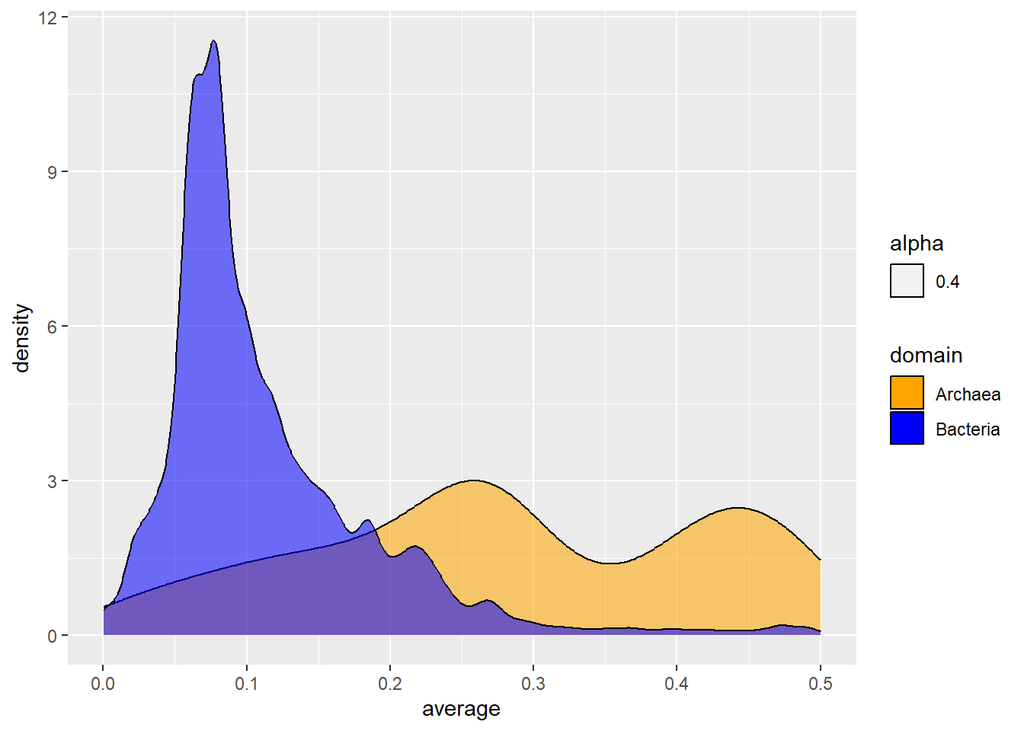

```r
ggplot(Pro_CN)+
  geom_density(aes(x=average, fill=domain, alpha=0.4))+
  scale_fill_manual(values=c("orange","blue"))
```

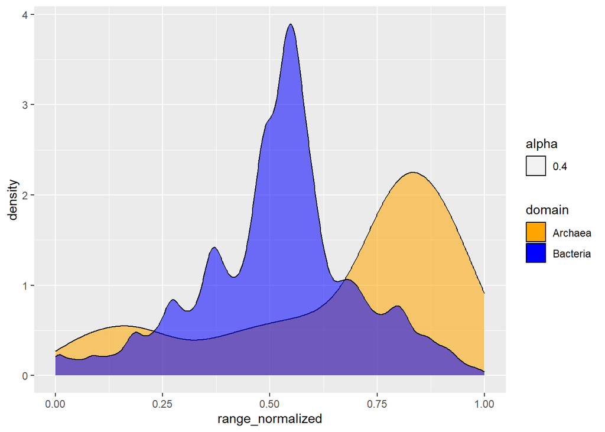

```r
ggplot(Pro_CN)+
  geom_density(aes(x=range_normalized, fill=domain, alpha=0.4))+
  scale_fill_manual(values=c("orange","blue"))
```

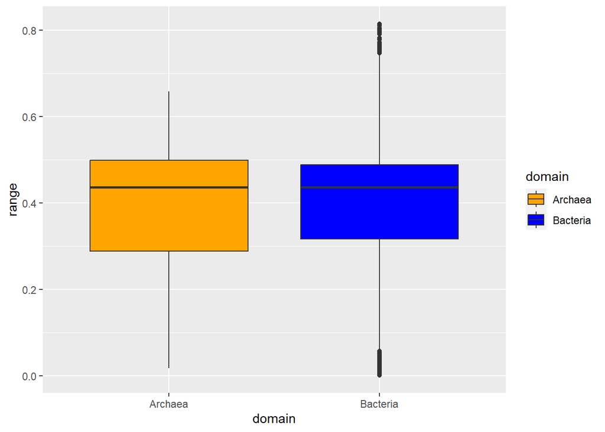

```r
    #Box plots
ggplot(Pro_CN, aes(x=domain, y=range, fill=domain))+
  geom_boxplot()+
  scale_fill_manual(values=c("orange","blue")) #Two modes suggested in Archaea; Bacteria lumpy
```

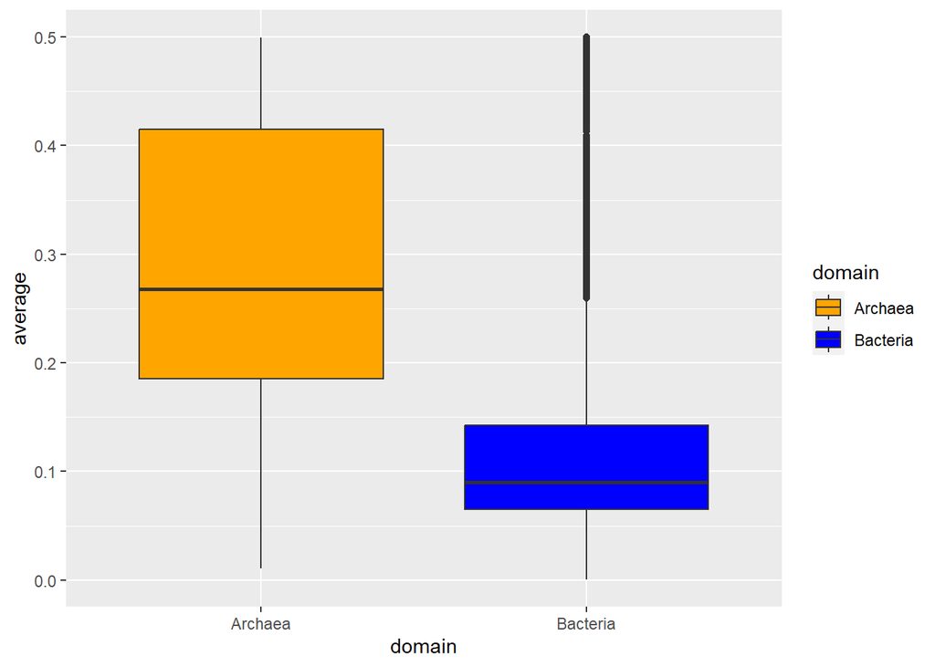

```r
ggplot(Pro_CN, aes(x=domain, y=average, fill=domain))+
  geom_boxplot()+
  scale_fill_manual(values=c("orange","blue")) #Two modes suggested in Archaea; Bacterial mostly normally distributed
```

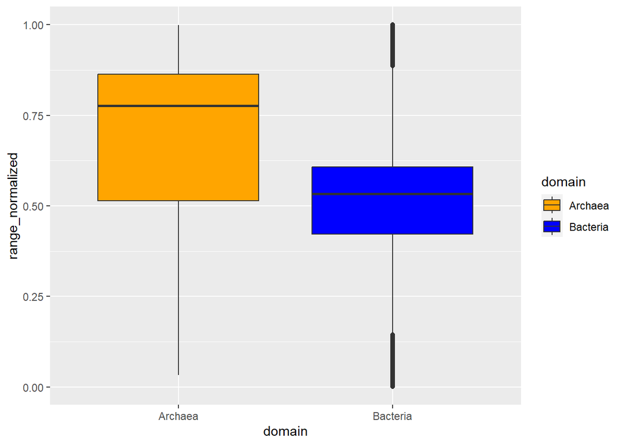

```r
ggplot(Pro_CN, aes(x=domain, y=range_normalized, fill=domain))+
  geom_boxplot()+
  scale_fill_manual(values=c("orange","blue"))
```

```r
    #Tests
wilcox.test(range~domain, data=Pro_CN) #not significant
```

```
##
##  Wilcoxon rank sum test with continuity correction
##
## data:  range by domain
## W = 2437240, p-value = 0.7598
## alternative hypothesis: true location shift is not equal to 0
```

```r
wilcox.test(average~domain, data=Pro_CN) #significant
```

```
##
##  Wilcoxon rank sum test with continuity correction
##
## data:  average by domain
## W = 4189875, p-value < 2.2e-16
## alternative hypothesis: true location shift is not equal to 0
```

```r
wilcox.test(range_normalized~domain, data=Pro_CN) #significant
```

```
##
##  Wilcoxon rank sum test with continuity correction
##
## data:  range_normalized by domain
## W = 3520390, p-value < 2.2e-16
## alternative hypothesis: true location shift is not equal to 0
```

## CN distribution cross domain (Matched for 2-5 CN)

```r
#Matched CN Bacteria vs. Total Archaea
table(Pro_CN$CN, Pro_CN$domain)
```

```
##
##      Archaea Bacteria
##   2      115     3357
##   3       69     3457
##   4        8     2871
##   5        2     2013
##   6        0     3787
##   7        0     5074
##   8        0     2577
##   9        0      623
##   10       0      687
##   11       0      346
##   12       0      224
##   13       0      121
##   14       0      245
##   15       0       26
##   16       0       13
##   17       0        8
##   18       0        4
##   19       0        3
##   20       0       14
```

```r
  #Archaea -> 1-5
  #Bacteria-> 1-20

Pro_CN_red <- Pro_CN[Pro_CN$CN <=5,]
table(Pro_CN_red$CN, Pro_CN_red$domain)
```

```
##
##     Archaea Bacteria
##   2     115     3357
##   3      69     3457
##   4       8     2871
##   5       2     2013
```

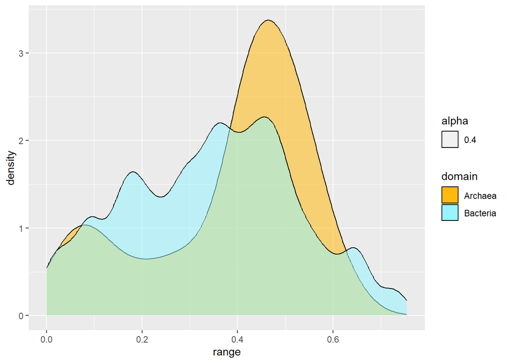

```r
    #Density plots
ggplot(Pro_CN_red)+
  geom_density(aes(x=range, fill=domain, alpha=0.4))+
  scale_fill_manual(values=c("darkgoldenrod1","cadetblue1"))
```

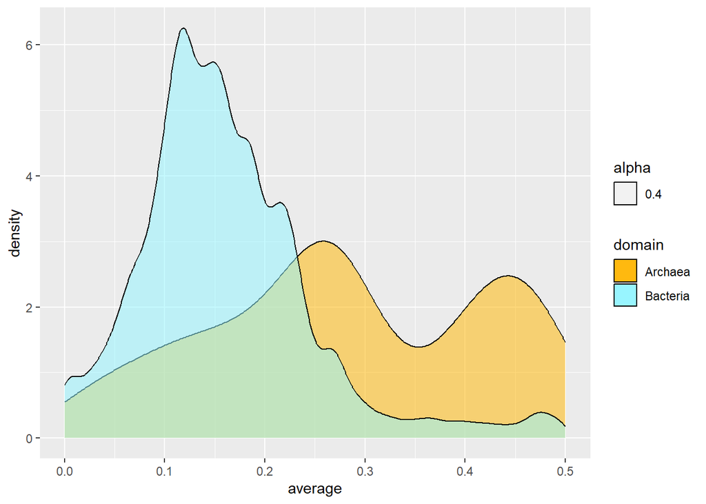

```r
ggplot(Pro_CN_red)+
  geom_density(aes(x=average, fill=domain, alpha=0.4))+
  scale_fill_manual(values=c("darkgoldenrod1","cadetblue1"))
```

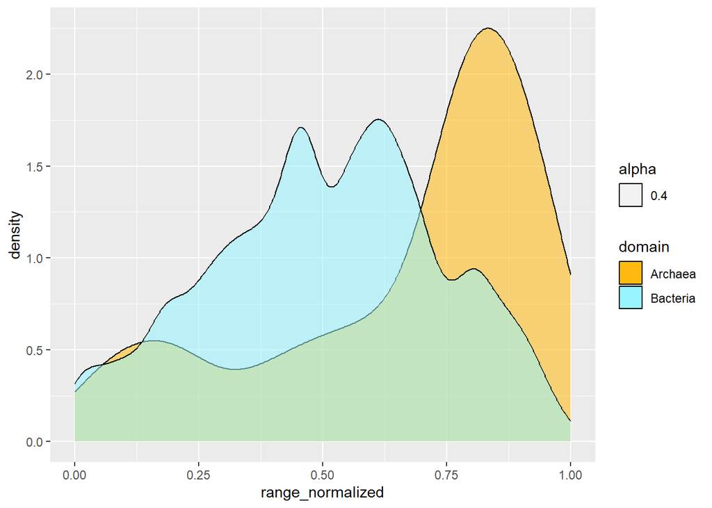

```r
ggplot(Pro_CN_red)+
  geom_density(aes(x=range_normalized, fill=domain, alpha=0.4))+
  scale_fill_manual(values=c("darkgoldenrod1","cadetblue1"))
```

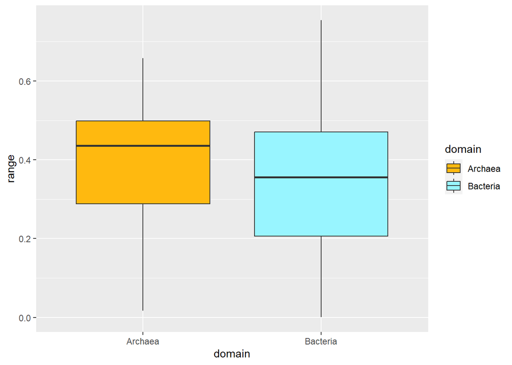

```r
    #Box Plots
ggplot(Pro_CN_red, aes(x=domain, y=range, fill=domain))+
  geom_boxplot()+
  scale_fill_manual(values=c("darkgoldenrod1","cadetblue1")) #Two modes suggested in Archaea; Bacteria lumpy
```

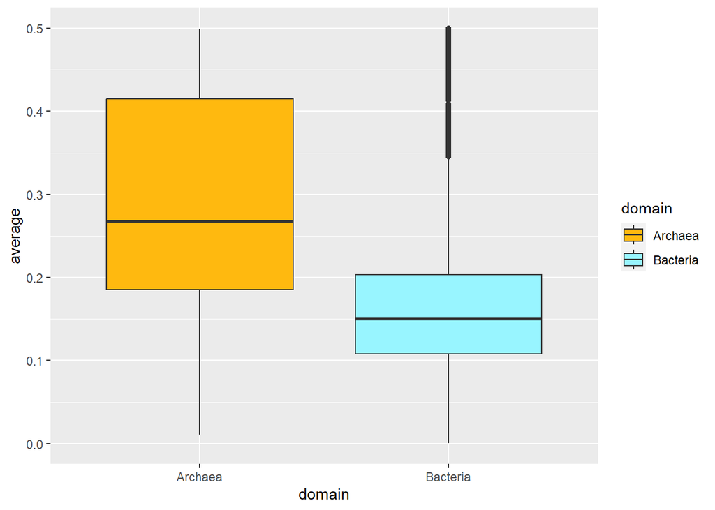

```r
ggplot(Pro_CN_red, aes(x=domain, y=average, fill=domain))+
  geom_boxplot()+
  scale_fill_manual(values=c("darkgoldenrod1","cadetblue1")) #Two modes suggested in Archaea; Bacterial mostly normally distributed
```

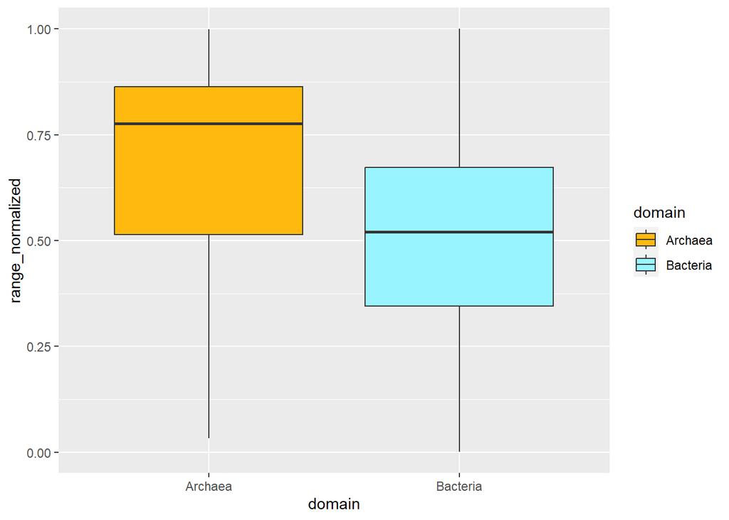

```r
ggplot(Pro_CN_red, aes(x=domain, y=range_normalized, fill=domain))+
  geom_boxplot()+
  scale_fill_manual(values=c("darkgoldenrod1","cadetblue1"))
```

```r
    #Basic Tests
wilcox.test(range~domain, data=Pro_CN_red) #significant
```

```
##
##  Wilcoxon rank sum test with continuity correction
##
## data:  range by domain
## W = 1326375, p-value = 5.312e-05
## alternative hypothesis: true location shift is not equal to 0
```

```r
wilcox.test(average~domain, data=Pro_CN_red) #significant
```

```
##
##  Wilcoxon rank sum test with continuity correction
##
## data:  average by domain
## W = 1737930, p-value < 2.2e-16
## alternative hypothesis: true location shift is not equal to 0
```

```r
wilcox.test(range_normalized~domain, data=Pro_CN_red) #significant
```

```
##
##  Wilcoxon rank sum test with continuity correction
##
## data:  range_normalized by domain
## W = 1584557, p-value < 2.2e-16
## alternative hypothesis: true location shift is not equal to 0
```

## CN distribution across domain and CN

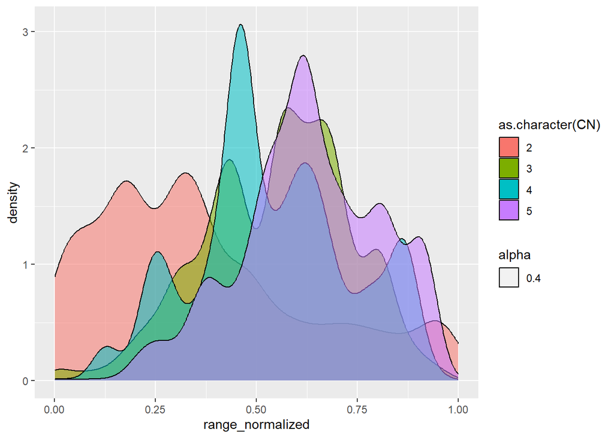

```r
  #Density Plots by CN (w/ Domain Separate)
ggplot(Pro_CN_red[Pro_CN_red$domain=="Bacteria",])+
  geom_density(aes(x=range_normalized, fill=as.character(CN), alpha=0.4))
```

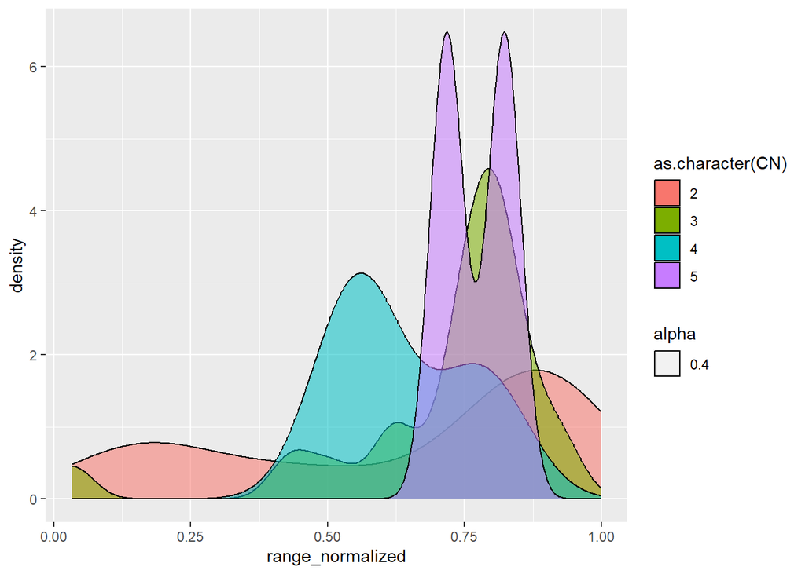

```r
ggplot(Pro_CN_red[Pro_CN_red$domain=="Archaea",])+
  geom_density(aes(x=range_normalized, fill=as.character(CN), alpha=0.4))
```

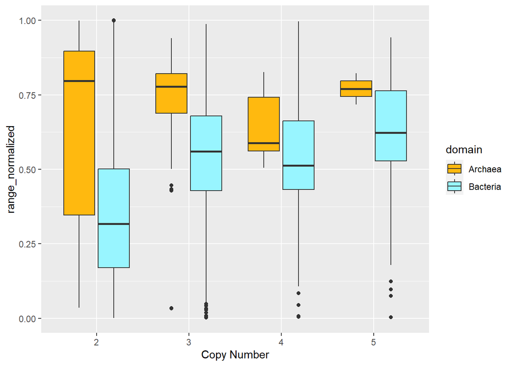

```r
  #Box Plots by CN and Domain
ggplot(Pro_CN_red, aes(y=range_normalized, x=as.character(CN), fill=domain))+
  geom_boxplot() +
  labs(x="Copy Number")+
  scale_fill_manual(values=c("darkgoldenrod1","cadetblue1"))
```

```r
  #update two bacterial phyla with range normalized of exactly 1
Pro_CN_red$range_normalized[Pro_CN_red$accession=="NC_008011"] <- 0.99999
Pro_CN_red$range_normalized[Pro_CN_red$accession=="NC_020127"] <- 0.99999

  #Beta regression model with domain, CN, and interaction
lm_avg_beta <- betareg(range_normalized ~ domain*as.character(CN), data = Pro_CN_red)
summary(lm_avg_beta)
```

```
##
## Call:
## betareg(formula = range_normalized ~ domain * as.character(CN), data = Pro_CN_red)
##
## Standardized weighted residuals 2:
##     Min      1Q  Median      3Q     Max
## -5.5637 -0.4882  0.0062  0.4949  9.7526
##
## Coefficients (mean model with logit link):
##                                  Estimate Std. Error z value Pr(>|z|)
## (Intercept)                       0.64520    0.08568   7.530 5.06e-14 ***
## domainBacteria                   -1.24558    0.08719 -14.285  < 2e-16 ***
## as.character(CN)3                 0.10209    0.14045   0.727  0.46733
## as.character(CN)4                -0.17867    0.33280  -0.537  0.59137
## as.character(CN)5                 0.26030    0.66678   0.390  0.69625
## domainBacteria:as.character(CN)3  0.65916    0.14218   4.636 3.55e-06 ***
## domainBacteria:as.character(CN)4  0.92391    0.33361   2.769  0.00562 **
## domainBacteria:as.character(CN)5  0.81542    0.66728   1.222  0.22170
##
## Phi coefficients (precision model with identity link):
##       Estimate Std. Error z value Pr(>|z|)
## (phi)  3.77919    0.04417   85.56   <2e-16 ***
## ---
## Signif. codes:  0 '***' 0.001 '**' 0.01 '*' 0.05 '.' 0.1 ' ' 1
##
## Type of estimator: ML (maximum likelihood)
## Log-likelihood:  1766 on 9 Df
## Pseudo R-squared: 0.146
## Number of iterations: 20 (BFGS) + 2 (Fisher scoring)
```

## CN distribution across phyla -Bacteria

## CN distribution across phyla -Archaea

## CN distribution across other characteristics

# Part 2: What is the phylogenetic signal of CN distribution?

## Setup of phylogenetic tree for Archaea

```r
# get tree in
setwd("C:/Users/Mark.Williamson.2/OneDrive - North Dakota University System/Desktop/Williamson Projects/Copy Number/CN Distribution/")
Arch_tree_new <- read.tree("Archaea_2023_CN_1plus_16S_rRNA_NORMRANGE.nwk") #Netwick, WORKED

# check characteristics
Arch_tree_new$Nnode #193
```

```
## [1] 193
```

```r
is.rooted(Arch_tree_new) #TRUE
```

```
## [1] TRUE
```

```r
is.ultrametric(Arch_tree_new) #TRUE
```

```
## [1] TRUE
```

```r
is.binary(Arch_tree_new) #TRUE
```

```
## [1] TRUE
```

```r
Arch_tree_new$root.edge <- 0

# modify tree to dend object
Arch_dend_new <- as.dendrogram(Arch_tree_new)

# create and list labels
Arch_labels_new <- Arch_tree_new$tip.label


#one line code to get out normalized range from tip label, where [1] is the first item of the Arch_labels
#za<-as.numeric(substr(strsplit(Arch_labels_new[1], split="__")[[1]][4],1,(nchar(strsplit(Arch_labels_new[1], #split="__")[[1]][4])-1)))
#za

# get distribution values from labels
CN_full_a <-c()
nrange_full_a <-c()

for (i in 1:length(Arch_labels_new)){
  c <- strsplit(Arch_labels_new[i], split = "__")[[1]][3]
  r <- strsplit(Arch_labels_new[i], split = "__")[[1]][4]
  r2 <- as.numeric(substr(r,1,(nchar(r)-1)))
  CN_full_a  <<-append(CN_full_a, as.double(c))
  nrange_full_a <<-append(nrange_full_a, as.double(r2))
}

head(Arch_tree_new$tip.label)
```

```
## [1] "'LR792634__Methanocaldococcus sp. SG1 genome assembly__2__0.8922'"
## [2] "'CP009149__Methanocaldococcus bathoardescens strain JH146__2__0.5322'"
## [3] "'000909__Methanocaldococcus jannaschii DSM 2661__2__0.5772'"
## [4] "'CP022242__Methanofervidicoccus sp. A16__2__0.5914'"
## [5] "'015847__Methanococcus maripaludis X1__2__0.0368'"
## [6] "'AP011526__Methanococcus maripaludis KA1__2__0.0348'"
```

```r
head(Arch_labels_new)
```

```
## [1] "'LR792634__Methanocaldococcus sp. SG1 genome assembly__2__0.8922'"
## [2] "'CP009149__Methanocaldococcus bathoardescens strain JH146__2__0.5322'"
## [3] "'000909__Methanocaldococcus jannaschii DSM 2661__2__0.5772'"
## [4] "'CP022242__Methanofervidicoccus sp. A16__2__0.5914'"
## [5] "'015847__Methanococcus maripaludis X1__2__0.0368'"
## [6] "'AP011526__Methanococcus maripaludis KA1__2__0.0348'"
```

```r
head(CN_full_a)
```

```
## [1] 2 2 2 2 2 2
```

```r
head(nrange_full_a)
```

```
## [1] 0.8922 0.5322 0.5772 0.5914 0.0368 0.0348
```

## Test of Phylogenetic signal for Archaea

```r
 #CN
phylosig(Arch_tree_new, CN_full_a, method="lambda", test=TRUE) #significant
```

```
## [1] "x has no names; assuming x is in the same order as tree$tip.label"
```

```
##
## Phylogenetic signal lambda : 0.991609
## logL(lambda) : -134.671
## LR(lambda=0) : 100.205
## P-value (based on LR test) : 1.37428e-23
```

```r
#phylosig(Arch_tree_new, CN_full_a, method="K", test = TRUE, nsim = 1000) #N/A

  #Normalized Range
phylosig(Arch_tree_new, nrange_full_a, method="lambda", test=TRUE) #significant
```

```
## [1] "x has no names; assuming x is in the same order as tree$tip.label"
```

```
##
## Phylogenetic signal lambda : 0.995466
## logL(lambda) : 62.5849
## LR(lambda=0) : 173.66
## P-value (based on LR test) : 1.17441e-39
```

```r
#phylosig(Arch_tree_new, nrange_full_a, method="K", test = TRUE, nsim = 1000) #N/A
```

## Setup of phylogenetic tree for Bacteria

```r
# get tree in
setwd("C:/Users/Mark.Williamson.2/OneDrive - North Dakota University System/Desktop/Williamson Projects/Copy Number/CN Distribution/")
Bact_tree_new <- read.newick("Bacteria_2023_CN_1plus_16S_rRNA_rarified_NORMRANGE.nwk")
# check characteristics
Bact_tree_new$Nnode #3979
```

```
## [1] 3979
```

```r
is.rooted(Bact_tree_new) #TRUE
```

```
## [1] TRUE
```

```r
Bact_tree_new <- force.ultrametric(Bact_tree_new, method = "extend")
```

```
## *                          Note:                              *
## *    force.ultrametric does not include a formal method to    *
## *    ultrametricize a tree & should only be used to coerce    *
## *   a phylogeny that fails is.ultramtric due to rounding --   *
## *    not as a substitute for formal rate-smoothing methods.   *
```

```r
is.ultrametric(Bact_tree_new) #TRUE
```

```
## [1] TRUE
```

```r
is.binary(Bact_tree_new) #TRUE
```

```
## [1] TRUE
```

```r
Bact_tree_new$root.edge <- 0

# modify tree to dend object
Bact_dend_new <- as.dendrogram(Bact_tree_new)

# create and list labels
Bact_labels_new <- Bact_tree_new$tip.label

# get distribution values from labels
CN_full_b <-c()
nrange_full_b <-c()

for (i in 1:length(Bact_labels_new)){
  c <- strsplit(Bact_labels_new[i], split = "__")[[1]][3]
  r <- strsplit(Bact_labels_new[i], split = "__")[[1]][4]
  r2 <- as.numeric(substr(r,1,(nchar(r)-1)))
  CN_full_b  <<-append(CN_full_b, as.double(c))
  nrange_full_b <<-append(nrange_full_b, as.double(r2))
}

head(Bact_tree_new$tip.label)
```

```
## [1] "'CP071182__Alicyclobacillus_mengziensis__8__0.783771429'"
## [2] "'013205__Alicyclobacillus_acidocaldarius__6__0.7044'"
## [3] "'AP023366__Effusibacillus_dendaii__9__0.8143875'"
## [4] "'CP024955__Kyrpidia_spormannii__5__0.6905'"
## [5] "'014098__Kyrpidia_tusciae__5__0.851'"
## [6] "'CP070969__Paenibacillus_tianjinensis__10__0.368333333'"
```

```r
head(Bact_labels_new)
```

```
## [1] "'CP071182__Alicyclobacillus_mengziensis__8__0.783771429'"
## [2] "'013205__Alicyclobacillus_acidocaldarius__6__0.7044'"
## [3] "'AP023366__Effusibacillus_dendaii__9__0.8143875'"
## [4] "'CP024955__Kyrpidia_spormannii__5__0.6905'"
## [5] "'014098__Kyrpidia_tusciae__5__0.851'"
## [6] "'CP070969__Paenibacillus_tianjinensis__10__0.368333333'"
```

```r
head(CN_full_b)
```

```
## [1]  8  6  9  5  5 10
```

```r
head(nrange_full_b)
```

```
## [1] 0.7837714 0.7044000 0.8143875 0.6905000 0.8510000 0.3683333
```

## Test of Phylogenetic signal for Bacteria

```r
#Don't rerun unless needed; took a long time

  #CN
phylosig(Bact_tree_new, CN_full_b, method="lambda", test=TRUE) #significant
  #Phylogenetic signal lambda : 0.995158
  #logL(lambda) : -5555.69
  #LR(lambda=0) : 6431.39
  #P-value (based on LR test) : 0


  #Normalized Range
phylosig(Bact_tree_new, nrange_full_b, method="lambda", test=TRUE) #significant
  #Phylogenetic signal lambda : 0.996987
  #logL(lambda) : 1407.22
  #LR(lambda=0) : 2077.03
  #P-value (based on LR test) : 0
```

## Circulos plots setup

```r
# double check created labels and trees
head(Arch_tree_new$tip.label)
```

```
## [1] "'LR792634__Methanocaldococcus sp. SG1 genome assembly__2__0.8922'"
## [2] "'CP009149__Methanocaldococcus bathoardescens strain JH146__2__0.5322'"
## [3] "'000909__Methanocaldococcus jannaschii DSM 2661__2__0.5772'"
## [4] "'CP022242__Methanofervidicoccus sp. A16__2__0.5914'"
## [5] "'015847__Methanococcus maripaludis X1__2__0.0368'"
## [6] "'AP011526__Methanococcus maripaludis KA1__2__0.0348'"
```

```r
head(Arch_labels_new)
```

```
## [1] "'LR792634__Methanocaldococcus sp. SG1 genome assembly__2__0.8922'"
## [2] "'CP009149__Methanocaldococcus bathoardescens strain JH146__2__0.5322'"
## [3] "'000909__Methanocaldococcus jannaschii DSM 2661__2__0.5772'"
## [4] "'CP022242__Methanofervidicoccus sp. A16__2__0.5914'"
## [5] "'015847__Methanococcus maripaludis X1__2__0.0368'"
## [6] "'AP011526__Methanococcus maripaludis KA1__2__0.0348'"
```

```r
head(CN_full_a)
```

```
## [1] 2 2 2 2 2 2
```

```r
head(nrange_full_a)
```

```
## [1] 0.8922 0.5322 0.5772 0.5914 0.0368 0.0348
```

```r
head(Arch_dend_new)
```

```
## --[dendrogram w/ 2 branches and 194 members at h = 1.39]
##   |--[dendrogram w/ 2 branches and 57 members at h = 0.354]
##   |  |--[dendrogram w/ 2 branches and 56 members at h = 0.311]
##   |  |  |--[dendrogram w/ 2 branches and 25 members at h = 0.283] ..
##   |  |  `--[dendrogram w/ 2 branches and 31 members at h = 0.14] ..
##   |  `--leaf "'LR216287__Candidatus Nitrosocosmicus franklandus isolate NFRAN1__2__0.1038'"
##   `--[dendrogram w/ 2 branches and 137 members at h = 0.358]
##      |--[dendrogram w/ 2 branches and 135 members at h = 0.31]
##      |  |--[dendrogram w/ 2 branches and 62 members at h = 0.144] ..
##      |  `--[dendrogram w/ 2 branches and 73 members at h = 0.281] ..
##      `--[dendrogram w/ 2 branches and 2 members at h = 0.00273]
##         |--leaf "'CP017922__Candidatus Nitrosocosmicus hydrocola strain G61__2__0.1232'"
##         `--leaf "'CP012850__Candidatus Nitrosocosmicus oleophilus strain MY3__3__0.60435'"
## etc...
```

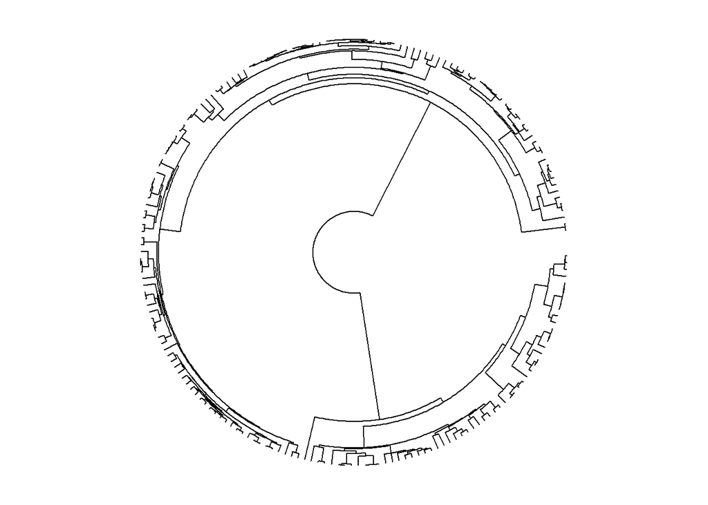

```r
#set up colors, lists, and sectors
col_fun <- colorRamp2(c(0, 1), c("white", "red"))
col_fun2 <- colorRamp2(c(1, 5), c("white", "blue"))
n <-length(Arch_tree_new$tip.label)
sectors_full = rep(letters[1], times =n)

dend_new_list <- list(a=Arch_dend_new)

CN_new_list   <- list(a=CN_full_a)
nrange_new_list<-list(a=nrange_full_a)

#test out tree w/ no heatmap
circos.par(cell.padding = c(0, 0, 0, 0), gap.degree = 5)
circos.initialize("a", xlim = c(0, length(sectors_full))) # only one sector
max_height = max(sapply(dend_new_list, function(x) attr(x, "height")))
circos.track(ylim = c(0, max_height), bg.border = NA, track.height = 0.8,
             panel.fun = function(x, y) {
               sector.index = get.cell.meta.data("sector.index")
               dend = dend_new_list[[sector.index]]
               circos.dendrogram(dend, max_height = max_height)
             })
```

```r
circos.clear()
```

full tree has 194 entries -> the number of Archaea w/ CN>1

## Creation of phylogenetic tree for Archaea -Normalized Range

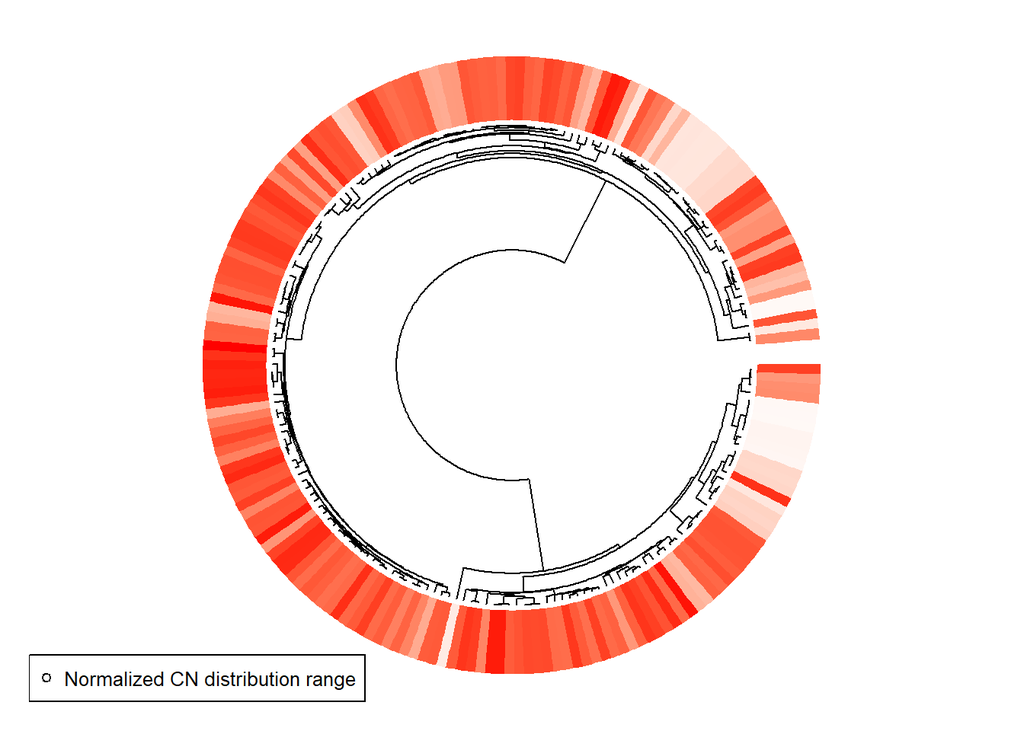

```r
#initialize circos
circos.par(cell.padding = c(0, 0, 0, 0), gap.degree = 5)
circos.initialize("a", xlim = c(0, length(sectors_full))) # only one sector

#heat map plot
circos.track(ylim = c(0, 1), bg.border = NA, panel.fun = function(x, y) {
  sector.index = CELL_META$sector.index
  m = nrange_new_list[[sector.index]]
  dend = dend_new_list[[sector.index]]
  col_mat = col_fun(m)
  nr = length(1:n)
  nc = 1
  circos.rect(1:nr - 1, rep(nc - 1, nr),
              1:nr, rep(nc - 1 + 1, nr),
              border = col_mat, col = col_mat)
})

#dendrogram plot
max_height = max(sapply(dend_new_list, function(x) attr(x, "height")))
circos.track(ylim = c(0, max_height), bg.border = NA, track.height = 0.4,
             panel.fun = function(x, y) {
               sector.index = get.cell.meta.data("sector.index")
               dend = dend_new_list[[sector.index]]
               circos.dendrogram(dend, max_height = max_height)
             })

#legend
legend("bottomleft", pch = 1, cex=0.8, legend = "Normalized CN distribution range")
```

```r
#clear
circos.clear()
```

## Creation of phylogenetic tree for Archaea -COPY NUMBER

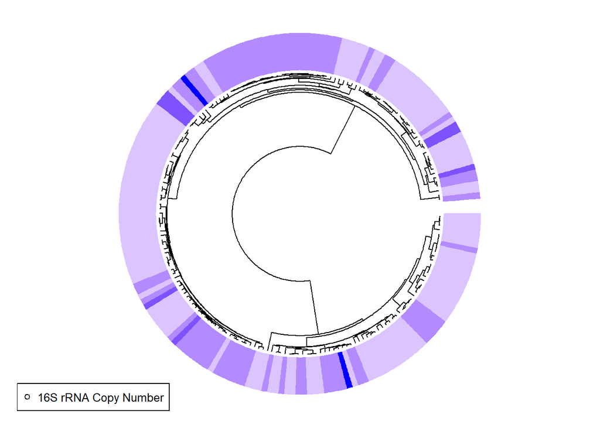

```r
#initialize circos
circos.par(cell.padding = c(0, 0, 0, 0), gap.degree = 5)
circos.initialize("a", xlim = c(0, length(sectors_full))) # only one sector

#heat map plot
circos.track(ylim = c(0, 1), bg.border = NA, panel.fun = function(x, y) {
  sector.index = CELL_META$sector.index
  m = CN_new_list[[sector.index]]
  dend = dend_new_list[[sector.index]]
  col_mat = col_fun2(m)
  nr = length(1:n)
  nc = 1
  circos.rect(1:nr - 1, rep(nc - 1, nr),
              1:nr, rep(nc - 1 + 1, nr),
              border = col_mat, col = col_mat)
})

#dendrogram plot
max_height = max(sapply(dend_new_list, function(x) attr(x, "height")))
circos.track(ylim = c(0, max_height), bg.border = NA, track.height = 0.4,
             panel.fun = function(x, y) {
               sector.index = get.cell.meta.data("sector.index")
               dend = dend_new_list[[sector.index]]
               circos.dendrogram(dend, max_height = max_height)
             })

#legend
legend("bottomleft", pch = 1, cex=0.8, legend = "16S rRNA Copy Number")
```

```r
#clear
circos.clear()
```

Reference for Phylogenetic signal: https://nhcooper123.github.io/pcm-primer-online/phylogenetic-signal-in-r.html ***

## # Part 3: Do CN distributions different across domain (Archaea vs. Bacteria)?

## covered in Part 1 blocks

### CN-distribution-basic-domain

### CN-distribution-CN-matched-domain

## ### CN-distribution-domain-and-CN

# Part 4: Do CN distributions cluster by taxa (for each CN)?

## Add normalized range to taxonomy (M4) datasets

```r
# add normalized range to M4 datasets
names(Pro_CN)
```

```
##  [1] "accession"          "domain"             "species"
##  [4] "CN"                 "range"              "average"
##  [7] "range_no_cross"     "average_no_cross"   "range_normalized"
## [10] "average_normalized" "CN_g2"
```

```r
range_norm_ds <-data.frame(accession=Pro_CN$accession, range_normalized=Pro_CN$range_normalized)
head(range_norm_ds)
```

```
##     accession range_normalized
## 1 NZ_CP056121        0.2794737
## 2 NZ_CP056120        0.2842105
## 3 NZ_CP056122        0.2892632
## 4 NZ_CP090501        0.4301053
## 5 NZ_CP090498        0.4301053
## 6 NZ_CP090487        0.4372632
```

```r
M4_bact<-merge(M4_bact, range_norm_ds, by="accession", all.x = TRUE)
M4_arch<-merge(M4_arch, range_norm_ds, by="accession", all.x = TRUE)

#update two bacterial phyla with range normalized of exactly 1
M4_bact$range_normalized[M4_bact$accession=="NC_008011"] <- 0.99999
M4_bact$range_normalized[M4_bact$accession=="NC_020127"] <- 0.99999
```

## Beta Regressions by bacterial phyla -UNUSED

```r
betalm_range_b_phyla <- betareg(range ~ phylum2, data = M4_bact)
summary(betalm_range_b_phyla) #significant
range_b_marg <- emmeans(betalm_range_b_phyla, ~ phylum2)
range_b_sum <- cld(range_b_marg,
          alpha   = 0.05,
          Letters = letters,         ###  Use lowercase letters for .group
          adjust  = "sidak")         ###  Tukey-adjusted comparisons
range_b_sum

betalm_average_b_phyla <- betareg(average ~ phylum2, data = M4_bact)
summary(betalm_average_b_phyla) #significant
avg_b_marg <- emmeans(betalm_average_b_phyla, ~ phylum2)
avg_b_sum <- cld(avg_b_marg,
          alpha   = 0.05,
          Letters = letters,
          adjust  = "sidak")
avg_b_sum
```

## Beta Regression by bacterial phyla - normalized range

```r
betalm_rangenorm_b_phyla <- betareg(range_normalized ~ phylum2, data = M4_bact)
summary(betalm_rangenorm_b_phyla) #significant
```

```
##
## Call:
## betareg(formula = range_normalized ~ phylum2, data = M4_bact)
##
## Standardized weighted residuals 2:
##     Min      1Q  Median      3Q     Max
## -8.2674 -0.3833  0.1019  0.3757 12.7377
##
## Coefficients (mean model with logit link):
##                                   Estimate Std. Error z value Pr(>|z|)
## (Intercept)                       0.380096   0.016883  22.514  < 2e-16 ***
## phylum2Bacteroidetes             -0.031126   0.030560  -1.019    0.308
## phylum2Campilobacterota          -0.409803   0.031694 -12.930  < 2e-16 ***
## phylum2Chlamydiae                -2.438714   0.084723 -28.784  < 2e-16 ***
## phylum2Cyanobacteria/Chloroplast  0.079191   0.060222   1.315    0.189
## phylum2Firmicutes                -0.218903   0.019519 -11.215  < 2e-16 ***
## phylum2Other                     -0.607605   0.048384 -12.558  < 2e-16 ***
## phylum2Proteobacteria            -0.415850   0.018027 -23.068  < 2e-16 ***
## phylum2Spirochaetes              -0.966727   0.071620 -13.498  < 2e-16 ***
## phylum2Tenericutes               -0.300244   0.048993  -6.128 8.88e-10 ***
## phylum2Verrucomicrobia            0.001059   0.078415   0.014    0.989
##
## Phi coefficients (precision model with identity link):
##       Estimate Std. Error z value Pr(>|z|)
## (phi)   5.7954     0.0476   121.7   <2e-16 ***
## ---
## Signif. codes:  0 '***' 0.001 '**' 0.01 '*' 0.05 '.' 0.1 ' ' 1
##
## Type of estimator: ML (maximum likelihood)
## Log-likelihood:  6741 on 12 Df
## Pseudo R-squared: 0.07431
## Number of iterations: 21 (BFGS) + 2 (Fisher scoring)
```

```r
rangenorm_b_marg <- emmeans(betalm_rangenorm_b_phyla, ~ phylum2)
rangenorm_b_sum <- cld(rangenorm_b_marg,
          alpha   = 0.05,
          Letters = letters,
          adjust  = "sidak")
rangenorm_b_sum
```

```
##  phylum2                   emmean      SE  df asymp.LCL asymp.UCL .group
##  Chlamydiae                 0.113 0.00833 Inf    0.0896     0.137  a
##  Spirochaetes               0.357 0.01598 Inf    0.3122     0.403   b
##  Other                      0.443 0.01119 Inf    0.4117     0.475    c
##  Proteobacteria             0.491 0.00158 Inf    0.4866     0.496     d
##  Campilobacterota           0.493 0.00670 Inf    0.4736     0.512     d
##  Tenericutes                0.520 0.01148 Inf    0.4875     0.552     de
##  Firmicutes                 0.540 0.00244 Inf    0.5333     0.547      ef
##  Bacteroidetes              0.586 0.00618 Inf    0.5689     0.604        g
##  Actinobacteria             0.594 0.00407 Inf    0.5824     0.605        g
##  Verrucomicrobia            0.594 0.01847 Inf    0.5419     0.646       fg
##  Cyanobacteria/Chloroplast  0.613 0.01372 Inf    0.5740     0.652        g
##
## Confidence level used: 0.95
## Conf-level adjustment: sidak method for 11 estimates
## P value adjustment: sidak method for 55 tests
## significance level used: alpha = 0.05
## NOTE: If two or more means share the same grouping letter,
##       then we cannot show them to be different.
##       But we also did not show them to be the same.
```

reference: https://rcompanion.org/handbook/J_02.html ***